# p8105_hw6_fwt2107

Felix Tran

November 17, 2018

# Problem 1

### Data cleaning

1. Read in the dataset from the Washington Post’s github page
2. Create a **city_state** variable to combine each homicide’s city and state
3. Remove all homicides which were recorded in Dallas, TX; Phoenix, AZ; Kansas City, MO; and Tulsa, AL
4. Transform **victim_age** into a numeric variable
5. Transform **victim_race** into a binary variable (white vs. non-white)
6. Create a **solved_binary** binary variable for the outcome of each homicide (1 (solved) vs. 0 (unsolved))

```r
data_url <- RCurl::getURL('https://raw.githubusercontent.com/washingtonpost/data-homicides/master/homicide-data.csv')

homicide_df <- readr::read_csv(data_url) %>%
  mutate(city_state = stringr::str_c(city, ', ',state)) %>%
  filter(!(city_state %in% c('Dallas, TX', 'Phoenix, AZ', 'Kansas City, MO',
                             'Tulsa, AL'))) %>%
  mutate(victim_age = as.numeric(victim_age),
         victim_race = ifelse(victim_race == "White", "white", "non-white"),
         solved_binary = ifelse(disposition == "Closed by arrest", 1, 0))
```

### Fitting a logistic regression model for resolved vs. unresolved homicides

```r
baltimore_log <- glm(solved_binary ~ victim_age + victim_sex + victim_race,
                     data = homicide_df, family = binomial())

baltimore_log %>%
  broom::tidy(.) %>%
  mutate(OR = exp(estimate),
         CI_lower_limit = exp(estimate - 1.96*std.error),
         CI_upper_limit = exp(estimate + 1.96*std.error)) %>%
  select(term, estimate, OR, CI_lower_limit, CI_upper_limit)
```

```
## # A tibble: 5 x 5
##   term              estimate    OR CI_lower_limit CI_upper_limit
##   <chr>                <dbl> <dbl>          <dbl>          <dbl>
## 1 (Intercept)        0.362   1.44           1.35           1.53
## 2 victim_age        -0.00147 0.999          0.997          1.000
## 3 victim_sexMale    -0.510   0.601          0.570          0.633
## 4 victim_sexUnknown -0.459   0.632          0.520          0.768
## 5 victim_racewhite   0.577   1.78           1.68           1.89
```

### Fitting a logistic regression model for resolved vs. unresolved homicides

### in all cities listed in the dataset

1. Wrote *logistic_regression()* function to output a tidied logistic regression results from the *glm()* function. Logistic regression was run to describe the logit transformation of the probability of a homicide being resolved as a function of the victim’s race, age, and sex.
2. Ran *logistic_regression()* on the homicides for each location in the dataset
3. Calculated the OR and 95% CI for victim race for each city
4. Created **city_state_order** variable to record the order of the OR’s of all the cities
5. Plotted the OR’s of a homicide being resolved for a white vs. non-white victim after adjusting for age and sex in order of increasing magnitude for all cities.

```r
logistic_regression <- function(df) {
  broom::tidy(glm(solved_binary ~ victim_age + victim_sex + victim_race,
                  data = df, family = binomial()))
}

regression_df <- homicide_df %>%
  group_by(city_state) %>%
  nest %>%
  mutate(log_results = map(data, logistic_regression)) %>%
  select(city_state, log_results) %>%
  unnest %>%
  filter(term == "victim_racewhite") %>%
  mutate(OR = exp(estimate),
         CI_lower_limit = exp(estimate - 1.96*std.error),
         CI_upper_limit = exp(estimate + 1.96*std.error)) %>%
  select(city_state, estimate, OR, CI_lower_limit, CI_upper_limit)

regression_df
```

```
## # A tibble: 47 x 5
##    city_state      estimate    OR CI_lower_limit CI_upper_limit
##    <chr>              <dbl> <dbl>          <dbl>          <dbl>
##  1 Albuquerque, NM   0.299  1.35           0.821           2.22
##  2 Atlanta, GA       0.284  1.33           0.761           2.32
##  3 Baltimore, MD     0.820  2.27           1.61            3.20
##  4 Baton Rouge, LA   0.404  1.50           0.702           3.20
##  5 Birmingham, AL   -0.0385 0.962          0.569           1.63
##  6 Boston, MA        2.17   8.73           3.59           21.2
##  7 Buffalo, NY       0.942  2.56           1.40            4.70
##  8 Charlotte, NC     0.584  1.79           1.03            3.12
##  9 Chicago, IL       0.576  1.78           1.36            2.32
## 10 Cincinnati, OH    1.14   3.14           1.82            5.43
## # ... with 37 more rows
```

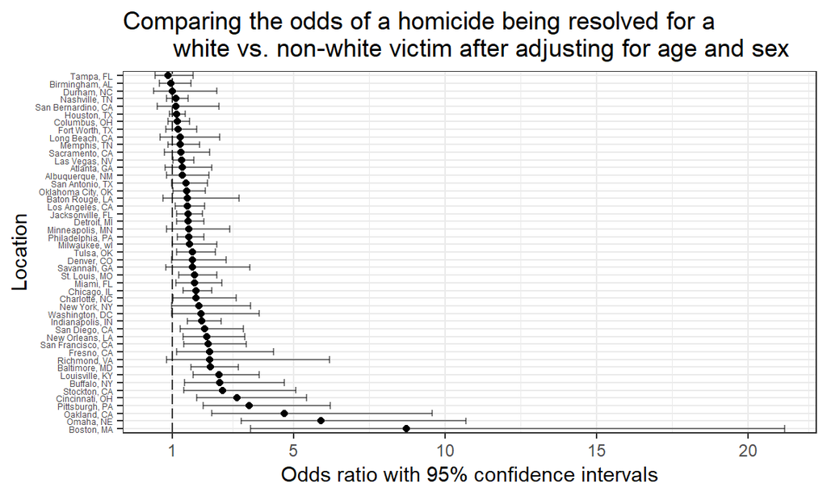

```r
city_state_order <- regression_df$city_state[order(regression_df$OR,
                                                   decreasing = T)]

regression_df %>%
  mutate(city_state = readr::parse_factor(city_state, city_state_order)) %>%
  ggplot(aes(x = city_state, y = OR)) +
  geom_point() +
  geom_errorbar(aes(ymin = CI_lower_limit, ymax = CI_upper_limit),
                alpha = 0.5) +
  geom_hline(yintercept = 1, linetype = "longdash", alpha = 0.75) +
  theme(axis.text.y = element_text(size = 4.5)) +
  labs(title = "Comparing the odds of a homicide being resolved for a
       white vs. non-white victim after adjusting for age and sex",
       x = "Location",
       y = "Odds ratio with 95% confidence intervals") +
  scale_y_continuous(breaks = c(1, 5, 10, 15, 20),
                     labels = c('1', '5', '10', '15', '20')) +
  coord_flip()
```

In all cities except Tampa, Birmingham, and Durham, after accounting for the victim’s age and sex, a homicide with a white victim has greater odds of being resolved compared to a non-white victim (without considering confidence intervals). There are a couple of outlier cities such as Boston and Oakland in which the odds of a homicide with a white victim being resolved are more than 2 times the odds of a homicide with a non-white victim being resolved. For several cities, the 95% confidence interval does not overlap with the null value of 1, which suggests the disparity between homicides with white vs. non-white victims is statistically significant.

# Problem 2

### Loading and cleaning the data

1. Load the dataset
2. Transform the variables for the baby’s sex, father’s and mother’s race, and presence of malformation into factors
3. Check if any variables have missing values

```r
birthweight_df <- readr::read_csv('./data/birthweight.csv') %>%
  mutate(babysex = recode_factor(babysex, `1` = 'Male', `2` = 'Female'),
         frace = recode_factor(frace, `1` = 'White', `2` = 'Black',
                               `3` = 'Asian', `4` = 'Puerto Rican',
                               `8` = 'Other', `9` = 'Unknown'),
         malform = recode_factor(malform, `0` = 'Absent', `1` = 'Present'),
         mrace = recode_factor(mrace, `1` = 'White', `2` = 'Black',
                               `3` = 'Asian', `4` = 'Puerto Rican',
                               `8` = 'Other'))
```

```r
map(birthweight_df, ~sum(is.na(.)))
```

```
## $babysex
## [1] 0
##
## $bhead
## [1] 0
##
## $blength
## [1] 0
##
## $bwt
## [1] 0
##
## $delwt
## [1] 0
##
## $fincome
## [1] 0
##
## $frace
## [1] 0
##
## $gaweeks
## [1] 0
##
## $malform
## [1] 0
##
## $menarche
## [1] 0
##
## $mheight
## [1] 0
##
## $momage
## [1] 0
##
## $mrace
## [1] 0
##
## $parity
## [1] 0
##
## $pnumlbw
## [1] 0
##
## $pnumsga
## [1] 0
##
## $ppbmi
## [1] 0
##
## $ppwt
## [1] 0
##
## $smoken
## [1] 0
##
## $wtgain
## [1] 0
```

### Proposing a regression model for birthweight

I propose a regression model which models birthweight by family income, gestational age, presence of malformations, average number of cigarettes smoked per day during pregnancy, and mother’s weight gain during pregnancy. These are factors which I believe would influence the birthweight of a baby.

1. Run a linear regression for my proposed model
2. Plot the residuals by predicted values of my proposed model

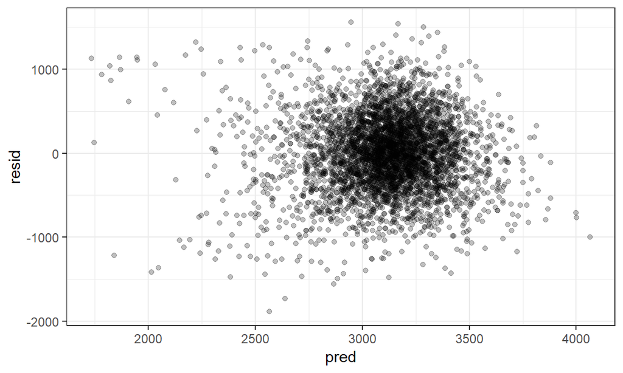

```r
my_model <- lm(data = birthweight_df, bwt ~ fincome + gaweeks + malform +
                 smoken + wtgain)

birthweight_df %>%
  add_predictions(my_model) %>%
  add_residuals(my_model) %>%
  ggplot(aes(x = pred, y = resid)) +
  geom_point(alpha = 0.25)
```

The majority of predicted values for my model lie within 500 grams of the actual value. There are a handful of outliers with large residuals for the smallest predicted values.

### Testing my proposed model against the other 2 models

1. Write functions for running linear regressions according to the specified model (my proposed model, main effects only, and all effects)
2. Write a function for calculating the root mean square error (RMSE) of each cross-validation for each of the three models
3. Make 100 different training and testing datasets based on the original data, and run all 3 models on those 100 sets of training and testing sets. Then compute the RMSE for every fitting of a model onto a set of training and testing data.
4. Graph the distribution of RMSE’s by the specified model.

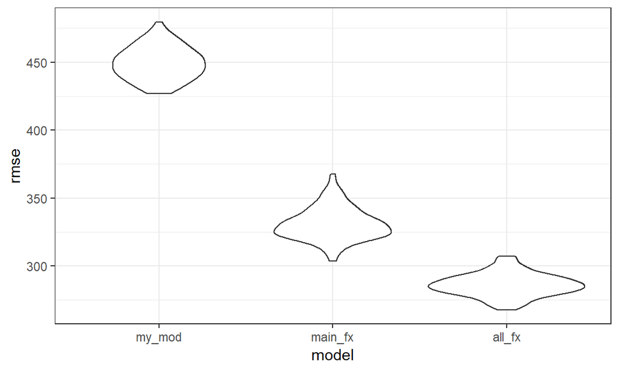

```r
my_model_regression <- function(df) {
  lm(data = df, bwt ~ fincome + gaweeks + malform + smoken + wtgain)
}

main_fx_regression <- function(df) {
  lm(data = df, bwt ~ blength + gaweeks)
}

all_fx_regression <- function(df) {
  lm(data = birthweight_df, bwt ~ bhead + blength + babysex +
                     bhead*blength + bhead*babysex + blength*babysex +
                     bhead*blength*babysex)
}

rmse_function <- function(df1, df2) {
  rmse(model = df1, data = df2)
}

cv_df <- crossv_mc(birthweight_df, 100) %>%
  mutate(train = map(train, as_tibble),
         test = map(test, as_tibble)) %>%
  mutate(my_mod = map(train, my_model_regression),
         main_fx_mod = map(train, main_fx_regression),
         all_fx_mod = map(train, all_fx_regression)) %>%
  mutate(rmse_my_mod = map2_dbl(my_mod, test, rmse_function),
         rmse_main_fx = map2_dbl(main_fx_mod, test, rmse_function),
         rmse_all_fx = map2_dbl(all_fx_mod, test, rmse_function))

cv_df %>%
  select(starts_with("rmse")) %>%
  gather(key = model, value = rmse) %>%
  mutate(model = str_replace(model, "rmse_", ""),
         model = fct_inorder(model)) %>%
  ggplot(aes(x = model, y = rmse)) + geom_violin()
```

Comparing the distribution of RMSE’s for the three models run over 100 different corss-validations, my proposed model (my_mod) has the largest average RMSE of the 3 models. The main effects only model (main_fx) performs better than my_mod, but the RMSE’s do not appear to be normally distributed. The model with all effects (all_fx) has the smallest average RMSE, and the RMSE’s appear to be normally distributed.